# Floating point arithmetic

Numerical Analysis

Urbain Vaes

NYU Paris

# Introduction

- Numerical algorithms usually assume exact operations.
- On computers, only a subset of real numbers can be stored.
- Many operations are approximate → leads to round-off errors.

**Chapter structure:**

- Binary representation of real numbers
- Floating point formats
- Arithmetic operations
- IEEE 754 encoding (Inf, -Inf, NaN)
- Integer formats

# Binary Representation of Real Numbers

A real number $x$ in base $\beta$ can be written as:

$$x = \pm \sum_{k=-n}^{\infty} a_k \beta^{-k}, \quad a_k \in \{0, \dots, \beta-1\}$$

- Humans: usually base 10
- Computers: usually base 2

## Common Bases

**Base 2 (binary)**

- Digits are 0 or 1
- Easy to store in circuits
- Multiplying/dividing by 2 = bit shifts

**Base 16 (hexadecimal)**

- Digits: 0–9, A–F
- Compact representation
- Used in colors, IPv6 addresses

## Conversion algorithm (Decimal → Binary)

Algorithm to convert a decimal fraction $x$ to binary:

```
Initialize i = 1
While x ≠ 0:
    Multiply x by 2
    If x ≥ 1:
        bᵢ = 1
        x = x - 1
    Else:
        bᵢ = 0
    i = i + 1
```

- Bits $b_1, b_2, …$ form the bits of the output $x = (0.b_1 b_2 …)_2$
- If $x$ repeats, binary representation is infinite
- Base 2 representation can be infinite even if base 10 representation is finite

## Example: $1/3$ in Binary

| i | $x$ | $2x$ | Bits so far |
| --- | --- | --- | --- |
| 1 | 1/3 | 2/3 | 0.**0** |
| 2 | 2/3 | 4/3 | 0.0**1** |
| 3 | 1/3 | 2/3 | 0.01**0** |
| 4 | 2/3 | 4/3 | 0.010**1** |
| 5 | 1/3 | 2/3 | 0.0101**0** |

Pattern repeats → $(1/3)_{10} = (0.\overline{01})_2$

# Set of Representable Values

- Computers store only a subset of real numbers.
- IEEE 754 standard defines floating point formats:

$$F(p, E_{min}, E_{max}) = \Big\{ (-1)^s 2^E (b_0.b_1 b_2 \dots b_{p-1})_2 \Big\}$$

**Parameters**:

- $p$: number of significant bits (**precision**)
- $E_{min}, E_{max}$: minimum and maximum exponents
- Special values: **Inf, -Inf, NaN**

## Components of a Floating Point Number

For $x \in F(p, E_{min}, E_{max})$:

- $s$ → **sign**
- $E$ → **exponent**
- $b_0.b_1 b_2 \dots b_{p-1}$ → **significand**
- $b_0$: leading bit

## Common Formats

| Format | Precision $p$ | $E_{min}$ | $E_{max}$ |
| --- | --- | --- | --- |
| Half (Float16) | 11 | -14 | 15 |
| Single (Float32) | 24 | -126 | 127 |
| Double (Float64) | 53 | -1022 | 1023 |

- $F_{16} \subset F_{32} \subset F_{64}$
- Half-precision introduced in IEEE 754-2008
- In Julia, `Float16`, `Float32`, `Float64` (default)

## Relative Error and Machine Epsilon

**Definition of the machine epsilon**

$$\varepsilon = 2^{-(p-1)}$$

- Depends on the floating point format (through parameter $p$)
- In Julia, `eps(Float16)`, `eps(Float32)`, `eps(Float64)`
- Indicates the maximum relative spacing between representable numbers
- **Example:** The next number from 1 is $1 + \varepsilon$

```julia
x = 1.0
println(nextfloat(x) - x)
println(eps(Float64))
```

```
2.220446049250313e-16
2.220446049250313e-16
```

## Absolute Density of Floating Point Numbers

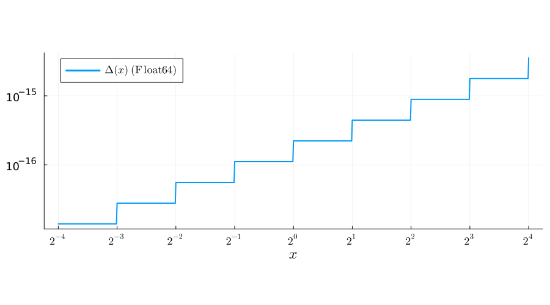

- More numbers near 0 → denser representation.
- Spacing grows with $|x|$.

## Relative Density of Floating Point Numbers

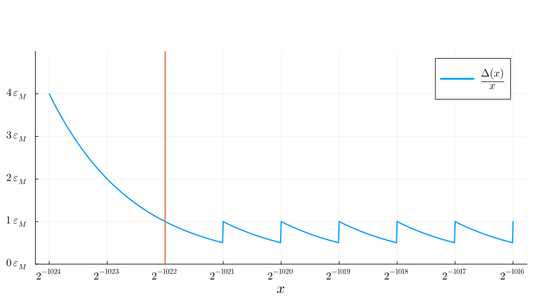

- Relative spacing oscillates between $\frac{1}{2} \varepsilon$ and $\varepsilon$ in normalized region
- In denormalized region (very small numbers), the relative spacing can be larger

# Arithmetic Operations and Rounding

- Floating point arithmetic is **not exact** due to limited precision.
- **Rounding:** result of any operation is rounded to nearest representable number.
- Each intermediate operation may introduce a small **round-off error**.
- Errors accumulate in sequences of operations.

```julia
ε = eps()
@show .1 + .2 == .3
@show sqrt(2)^2 == 2
@show exp(ε) == 1 + ε
@show exp(ε/2) == 1 + ε
@show exp(ε/3) == 1;
```

```
0.1 + 0.2 == 0.3 = false
sqrt(2) ^ 2 == 2 = false
exp(ε) == 1 + ε = true
exp(ε / 2) == 1 + ε = true
exp(ε / 3) == 1 = true
```

# Encoding of Floating Point Numbers

- Set of representable numbers specified by $(p, E_{min}, E_{max})$
- Encoding = how they are actually stored
- Encoding does not affect magnitude or propagation of round-off errors.

## Unique Representation Rules

**Unique Representation**

The representation of a representable number as $(-1)^s 2^E (b_0.b_1 … b_{p-1})_2$ is unique by requiring that

- Either $E > E_{min}$ and leading bit $b_0 = 1$
- Or $E = E_{min}$, then $b_0$ may be 0
- **Storage in memory**: `Float16`, `Float32`, `Float64` use 16, 32, 64 bits.
- Example layout (32-bit Float32):
  - Sign: 1 bit
  - Encoded exponent: 8 bits
  - Encoded significand: 23 bits